# ABV vs. IBU comparison for US Craft Beers

Aaron Cattley and Bruce Lee

2/18/2019

# Introduction:

# This will review the basic statistics of U.S. craft beer. There are 2410 beers across 558 U.S. breweries that will be a part of this study. The two separate datasets Budweiser supplied were used concurrently to develop these statistics.

```r
## First we've brought the datasets into our Rmd and created a list of how many breweries there are by state.
fileLocation <- "https://raw.githubusercontent.com/BruceLeeSMU/CaseStudy1/master/Breweries.csv"
breweryData <- read.csv(url(fileLocation))

brewery.byState <- count(breweryData, State)
names(brewery.byState) <- c("State", "NumPerState")
head(brewery.byState)
```

```
## # A tibble: 6 x 2
##   State NumPerState
##   <fct>       <int>
## 1 " AK"           7
## 2 " AL"           3
## 3 " AR"           2
## 4 " AZ"          11
## 5 " CA"          39
## 6 " CO"          47
```

```r
tail(brewery.byState)
```

```
## # A tibble: 6 x 2
##   State NumPerState
##   <fct>       <int>
## 1 " VA"          16
## 2 " VT"          10
## 3 " WA"          23
## 4 " WI"          20
## 5 " WV"           1
## 6 " WY"           4
```

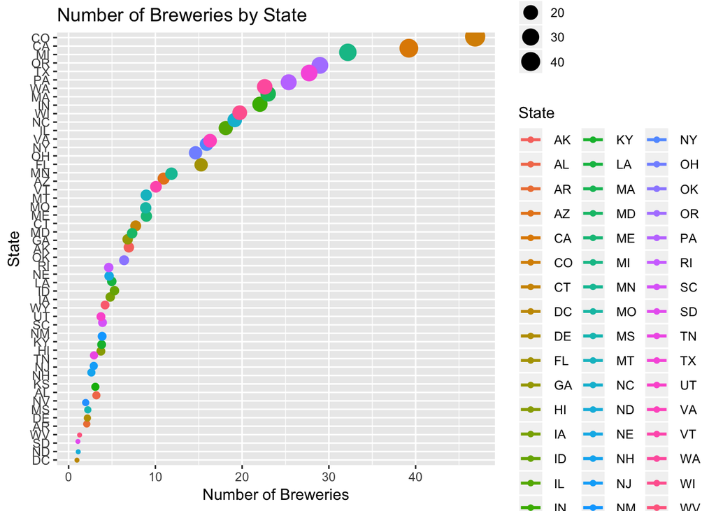

```r
Stateplot <- ggplot(brewery.byState, aes(x=reorder(State, NumPerState), y = NumPerState, colour = State)) + geom_jitter(aes(col=State, size = NumPerState)) + geom_smooth(aes(col=State), method = "lm", se=F) + labs(title = "Number of Breweries by State", x = "State", y = "Number of Breweries")+ coord_flip()
Stateplot
```

# We’ve built a list of breweries by state. Based on this list: Colorado, California, Michigan, Oregon and Texas have the highest number of breweries. The states with a lower number of breweries appear to be more related to being geographically based in more rural states than the size of the state.

```r
## We'll use the beer data set and merge it with the brewery data set.  We will show some examples of how this combined data frame looks.
fileLocation2 <- "https://raw.githubusercontent.com/BruceLeeSMU/CaseStudy1/master/Beers.csv"
beerData <- read.csv(url(fileLocation2))

breweryAndBeerData <- merge(breweryData, beerData, by.x="Brew_ID", by.y="Brewery_id")

head(breweryAndBeerData, 6)
```

```
##   Brew_ID             Name.x        City State        Name.y Beer_ID   ABV
## 1       1 NorthGate Brewing  Minneapolis    MN       Pumpion    2689 0.060
## 2       1 NorthGate Brewing  Minneapolis    MN    Stronghold    2688 0.060
## 3       1 NorthGate Brewing  Minneapolis    MN   Parapet ESB    2687 0.056
## 4       1 NorthGate Brewing  Minneapolis    MN  Get Together    2692 0.045
## 5       1 NorthGate Brewing  Minneapolis    MN Maggie's Leap    2691 0.049
## 6       1 NorthGate Brewing  Minneapolis    MN    Wall's End    2690 0.048
##   IBU                               Style Ounces
## 1  38                         Pumpkin Ale     16
## 2  25                     American Porter     16
## 3  47 Extra Special / Strong Bitter (ESB)     16
## 4  50                        American IPA     16
## 5  26                  Milk / Sweet Stout     16
## 6  19                   English Brown Ale     16
```

```r
tail(breweryAndBeerData, 6)
```

```
##      Brew_ID                        Name.x          City State
## 2405     556         Ukiah Brewing Company         Ukiah    CA
## 2406     557       Butternuts Beer and Ale Garrattsville    NY
## 2407     557       Butternuts Beer and Ale Garrattsville    NY
## 2408     557       Butternuts Beer and Ale Garrattsville    NY
## 2409     557       Butternuts Beer and Ale Garrattsville    NY
## 2410     558 Sleeping Lady Brewing Company     Anchorage    AK
##                         Name.y Beer_ID   ABV IBU                   Style
## 2405             Pilsner Ukiah      98 0.055  NA         German Pilsener
## 2406         Porkslap Pale Ale      49 0.043  NA American Pale Ale (APA)
## 2407           Snapperhead IPA      51 0.068  NA            American IPA
## 2408         Moo Thunder Stout      50 0.049  NA      Milk / Sweet Stout
## 2409  Heinnieweisse Weissebier      52 0.049  NA              Hefeweizen
## 2410 Urban Wilderness Pale Ale      30 0.049  NA        English Pale Ale
##      Ounces
## 2405     12
## 2406     12
## 2407     12
## 2408     12
## 2409     12
## 2410     12
```

# The newly merged dataset is ordered by the by the Brew ID. A sample of the beginning and ending variables are shown for example.

```r
## Data sets sometimes have NA's for various reasons; we'll extract those values for representational purposes.
str(breweryAndBeerData)
```

```
## 'data.frame':    2410 obs. of  10 variables:
##  $ Brew_ID: int  1 1 1 1 1 1 2 2 2 2 ...
##  $ Name.x : Factor w/ 551 levels "10 Barrel Brewing Company",..: 355 355 355 355 355 355 12 12 12 12 ...
##  $ City   : Factor w/ 384 levels "Abingdon","Abita Springs",..: 228 228 228 228 228 228 200 200 200 200 ...
##  $ State  : Factor w/ 51 levels " AK"," AL"," AR",..: 24 24 24 24 24 24 18 18 18 18 ...
##  $ Name.y : Factor w/ 2305 levels "#001 Golden Amber Lager",..: 1640 1926 1525 802 1258 2185 71 458 1218 43 ...
##  $ Beer_ID: int  2689 2688 2687 2692 2691 2690 2683 2686 2685 2684 ...
##  $ ABV    : num  0.06 0.06 0.056 0.045 0.049 0.048 0.042 0.08 0.125 0.077 ...
##  $ IBU    : int  38 25 47 50 26 19 42 68 80 25 ...
##  $ Style  : Factor w/ 100 levels "","Abbey Single Ale",..: 83 22 57 16 77 48 18 12 46 77 ...
##  $ Ounces : num  16 16 16 16 16 16 16 16 16 16 ...
```

```r
## Rename the Name.x and Name.y columns from after merging
colnames(breweryAndBeerData)[2] <- "BreweryName"
colnames(breweryAndBeerData)[5] <- "BeerName"

summary(breweryAndBeerData)
```

```
##     Brew_ID                          BreweryName             City
##  Min.   :  1.0   Brewery Vivant            :  62   Grand Rapids:  66
##  1st Qu.: 94.0   Oskar Blues Brewery       :  46   Portland    :  64
##  Median :206.0   Sun King Brewing Company  :  38   Chicago     :  55
##  Mean   :232.7   Cigar City Brewing Company:  25   Indianapolis:  43
##  3rd Qu.:367.0   Sixpoint Craft Ales       :  24   San Diego   :  42
##  Max.   :558.0   Hopworks Urban Brewery    :  23   Boulder     :  41
##                  (Other)                   :2192   (Other)     :2099
##      State                        BeerName       Beer_ID
##   CO    : 265   Nonstop Hef Hop       :  12   Min.   :   1.0
##   CA    : 183   Dale's Pale Ale       :   6   1st Qu.: 808.2
##   MI    : 162   Oktoberfest           :   6   Median :1453.5
##   IN    : 139   Longboard Island Lager:   4   Mean   :1431.1
##   TX    : 130   1327 Pod's ESB        :   3   3rd Qu.:2075.8
##   OR    : 125   Boston Lager          :   3   Max.   :2692.0
##  (Other):1406   (Other)               :2376
##       ABV               IBU                                    Style
##  Min.   :0.00100   Min.   :  4.00   American IPA                  : 424
##  1st Qu.:0.05000   1st Qu.: 21.00   American Pale Ale (APA)       : 245
##  Median :0.05600   Median : 35.00   American Amber / Red Ale      : 133
##  Mean   :0.05977   Mean   : 42.71   American Blonde Ale           : 108
##  3rd Qu.:0.06700   3rd Qu.: 64.00   American Double / Imperial IPA: 105
##  Max.   :0.12800   Max.   :138.00   American Pale Wheat Ale       :  97
##  NA's   :62        NA's   :1005     (Other)                       :1298
##      Ounces
##  Min.   : 8.40
##  1st Qu.:12.00
##  Median :12.00
##  Mean   :13.59
##  3rd Qu.:16.00
##  Max.   :32.00
##
```

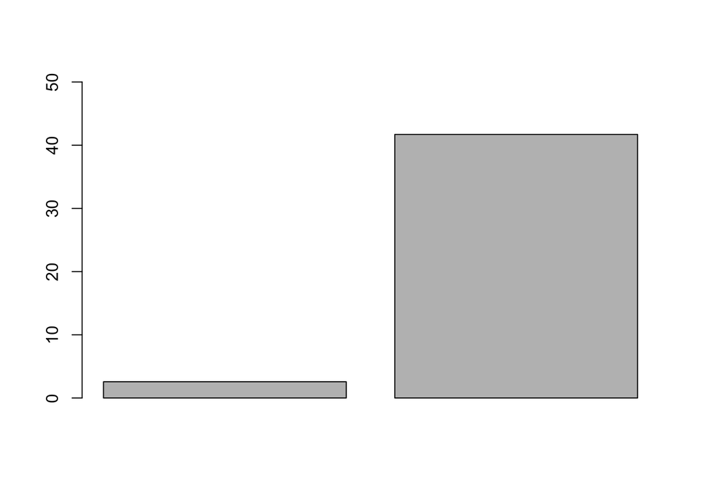

```r
num.NA.ABV <- length(which(is.na(breweryAndBeerData$ABV)))
num.NA.IBU <- length(which(is.na(breweryAndBeerData$IBU)))

num.NA <- data.frame(((num.NA.ABV/2410)*100),((num.NA.IBU/2410)*100))
colnames(num.NA) <- c("ABV", "IBU")
num.NA <- stack(num.NA)
num.NA <- as.vector(num.NA)

barplot(num.NA$values, ylim = c(0,50))
```

```r
## From the summary of the data set, NA's are only present in the ABV and IBU columns where ABV has 62 NA values and IBU has 1005 NA values.
```

#Due to the large dataset we are working with, the lack of available data due the NA’s will not impact the statistical analysis.

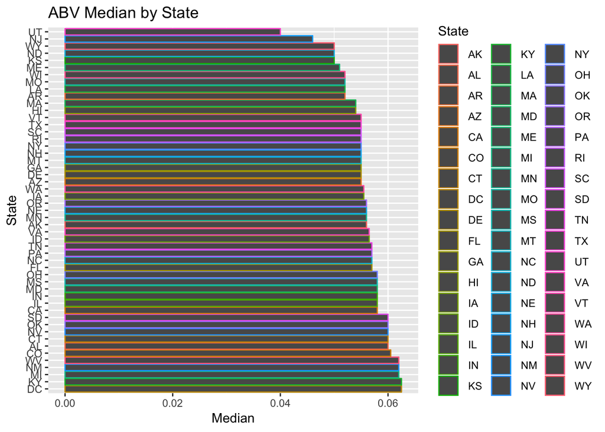

```r
#The next chunk of code will calculate the medians for both the ABV and IBU of all beers in the data set. Histograms will also be coded for visualization.
ABVMed <- aggregate(breweryAndBeerData$ABV ~ breweryAndBeerData$State, data = breweryAndBeerData, median)
colnames(ABVMed) <- c("State", "ABV")
ABVMed <- ABVMed[order(ABVMed$ABV, decreasing = T),]

IBUMed <- aggregate(breweryAndBeerData$IBU ~ breweryAndBeerData$State, data = breweryAndBeerData, median)
colnames(IBUMed) <- c("State", "IBU")
IBUMed <- IBUMed[order(IBUMed$IBU, decreasing = T),]

ABVplot <- ggplot(ABVMed, aes(x=reorder(State, -ABV), y = ABV, colour = State)) + geom_bar(stat = "Identity") + labs(title = "ABV Median by State", x = "State", y = "Median")+ coord_flip()
ABVplot
```

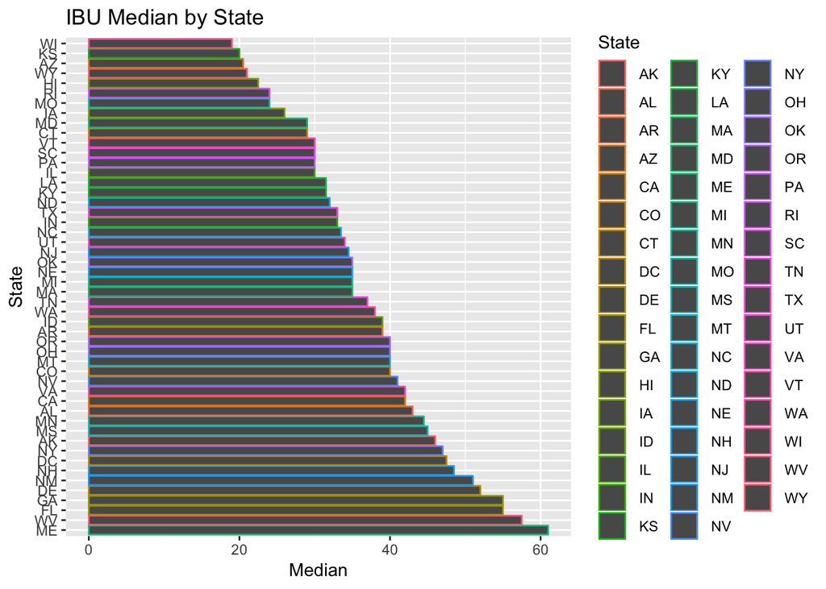

```r
IBUplot <- ggplot(IBUMed, aes(x=reorder(State, -IBU), y = IBU, colour = State)) + geom_bar(stat = "Identity") + labs(title = "IBU Median by State", x = "State", y = "Median")+ coord_flip()
IBUplot
```

# We’ve plotted the ABV and IBU with histograms. They’ve been ordered from largest to smallest.

```r
#Identify the State with the highest ABV beer
head(ABVMed, 1)
```

```
##   State    ABV
## 8    DC 0.0625
```

```r
#Identify the State with the highest IBU beer
head(IBUMed, 1)
```

```
##    State IBU
## 22    ME  61
```

```r
#The following code will provide a summary of statistics for the ABV.
summary(breweryAndBeerData$ABV)
```

```
##    Min. 1st Qu.  Median    Mean 3rd Qu.    Max.    NA's
## 0.00100 0.05000 0.05600 0.05977 0.06700 0.12800      62
```

[figure not shown]

```r
#Finally, we will build a scatterplot of the relationship between ABV and IBU
breweryAndBeerData2 <- na.omit(breweryAndBeerData)

BandBplot <- ggplot(breweryAndBeerData2, aes(x = breweryAndBeerData2$ABV, y = breweryAndBeerData2$IBU)) + geom_point(size = 2, shape = 23) + geom_point(aes(x=breweryAndBeerData2$ABV, y=breweryAndBeerData2$IBU, color = breweryAndBeerData2$State == 'KY' | breweryAndBeerData2$State == 'DC', size = breweryAndBeerData2$State == 'KY' | breweryAndBeerData2$State == 'DC')) +
  scale_color_manual(values = c("black", "red")) + scale_size_manual(values =c(1, 3)) + theme(legend.position = "none") +  geom_smooth(method= "lm") + labs(title = "Relationship between ABV and IBU", x = "ABV", y = "IBU") + theme(plot.title = element_text(hjust = 0.5))
BandBplot
```

# The scatterplot shows a trend that increasing ABV in beer also increases the bitter taste.

# To strengthen our findings, a correlation test was run and there was significant evidence at the alpha level of 0.05 level of significance to suggest that the ABV and IBU are linearly correlated (p < 0.0001)!

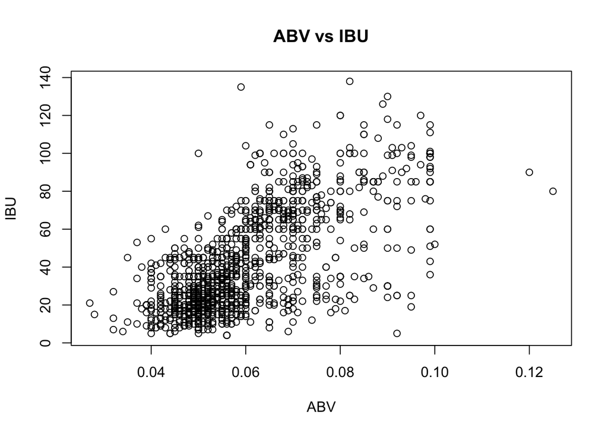

```r
plot(breweryAndBeerData2$ABV, breweryAndBeerData2$IBU, xlab='ABV', ylab='IBU', main = 'ABV vs IBU')
```

```r
cor.test(breweryAndBeerData2$ABV, breweryAndBeerData2$IBU)
```

```
##
##  Pearson's product-moment correlation
##
## data:  breweryAndBeerData2$ABV and breweryAndBeerData2$IBU
## t = 33.863, df = 1403, p-value < 2.2e-16
## alternative hypothesis: true correlation is not equal to 0
## 95 percent confidence interval:
##  0.6407982 0.6984238
## sample estimates:
##       cor
## 0.6706215
```